# Simulated data example for BayesNSGP

Mark Risser

10 April 2020

```r
N <- 400
set.seed(0)
coords <- matrix(runif(2*N, max = 10), ncol = 2)
coords_z <- coords/10
Xmat1 <- cbind(rep(1,N), coords_z[,1])
Xmat2 <- cbind(rep(1,N), coords_z[,2])
Xmat3 <- cbind(rep(1,N), coords_z[,1], coords_z[,2])
beta_true <- c(0, 2)
delta_true <- c(-1.75, 0.75)
alpha_true <- c(-0.5, 1.5, 0.5)
mean_vec <- as.numeric(Xmat2 %*% beta_true) # Mean
logSpatSD_vec <- as.numeric(Xmat3 %*% alpha_true) # Log spatial SD
logNuggSD_vec <- as.numeric(Xmat1 %*% delta_true) # Log nugget SD
dist_list <- nsDist(coords)
Cor_mat <- nsCorr( dist1_sq = dist_list$dist1_sq,
                   dist2_sq = dist_list$dist2_sq, dist12 = dist_list$dist12,
                   Sigma11 = rep(1, N), Sigma22 = rep(2, N),
                   Sigma12 = rep(0, N), nu = 0.5 )
Cov_mat <- diag(exp(logSpatSD_vec)) %*% Cor_mat %*% diag(exp(logSpatSD_vec))
D_mat <- diag(exp( logNuggSD_vec )^2)
# Draw data
set.seed(1)
data <- as.numeric(mean_vec + t(chol(Cov_mat + D_mat)) %*% rnorm(N))
```

### Model and MCMC setup

Suppose the we would like to fit a nonstationary model to this data set, using a log-linear regression model for $\tau(\cdot)$ (linear in the $x$-coordinate), the spatially-constant model for ${\bf \Sigma}(\cdot)$, linear regression for $\mu(\cdot)$ (linear in the $y$-coordinate), and an approximate GP for $\sigma(\cdot)$ (using a regular grid of $K=16$ knots over the domain). Furthermore, we will use the SGV likelihood with $k=10$ neighbors. The required constants can be set up as

```r
# Set up the knot coordinates
knot_coords <- expand.grid(x = seq(from = 0, to = 10, length = 4),
                           y = seq(from = 0, to = 10, length = 4))
knot_coords_mat <- as.matrix(knot_coords)
# Other constants for the model
constants <- list( X_tau = Xmat1, X_mu = Xmat2, Sigma_HP1 = max(dist(coords)),
                   sigma_knot_coords = knot_coords_mat,
                   maxAbsLogSD = 5, k = 10, nu = 0.5 )
```

(note that we limit the `maxAbsLogSD` to avoid numerically singular covariance matrices) and we can build the model with

```r
Rmodel <- nsgpModel( likelihood = "SGV", sigma_model = "approxGP",
                     Sigma_model = "constant", mu_model = "linReg",
                     tau_model = "logLinReg", constants = constants,
                     coords = coords, data = data )
```

Once the model has been built, the first step is to configure the MCMC:

```r
conf <- configureMCMC(Rmodel)
```

The default samplers can be queried with:

```r
conf$printSamplers()
```

```
## [1]  RW sampler: sigmaGP_mu
## [2]  RW sampler: sigmaGP_phi
## [3]  RW sampler: sigmaGP_sigma
## [4]  RW sampler: delta[1]
## [5]  RW sampler: delta[2]
## [6]  RW sampler: Sigma_coef1
## [7]  RW sampler: Sigma_coef2
## [8]  RW sampler: Sigma_coef3
## [9]  RW sampler: beta[1]
## [10] RW sampler: beta[2]
## [11] RW_block sampler: w_sigma[1:16]
```

```r
conf$removeSamplers()
```

```r
conf$addSampler(target = c("delta[1]","delta[2]"), type = "RW_block", silent = TRUE)
conf$addSampler(target = c("beta[1]","beta[2]"), type = "RW_block", silent = TRUE)
conf$addSampler(target = c("Sigma_coef1","Sigma_coef2"), type = "RW_block", silent = TRUE)
conf$addSampler(target = c("sigmaGP_phi","sigmaGP_sigma"), type = "RW_block", silent = TRUE)
conf$addSampler(target = c("Sigma_coef3"), type = "RW")
conf$addSampler(target = c("sigmaGP_mu"), type = "slice")
conf$addSampler(target = c("sigmaGP_phi","sigmaGP_sigma"), type = "AF_slice")
```

Finally, in order to sample the latent process values `w_sigma[1:16]`, a single large block sampler is likely to be ineffective; on the other hand, a large number of univariate samplers (in this case, 16) will slow down the MCMC and be inefficient as these parameters are likely to display a large degree of posterior correlation. Using `nimble`, however, we can quickly compare three different sampling schemes for these values:

1. One large block sampler: sample all 16 parameters simultaneously
2. Two block samplers: split the 16 parameters into two spatial sub-blocks (split along the $y$-coordinate)
3. Four small block samplers: split the 16 parameters into four spatial sub-blocks

A schematic of the three sampling schemes is

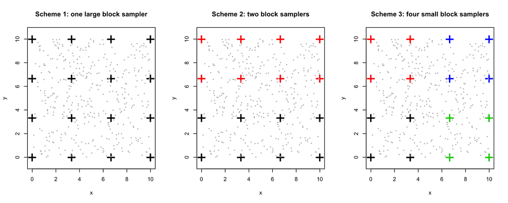

Using the `nimble` functionality, it is straightforward to implement each of these samplers. For example, the second scheme (with two block samplers) can be specified as follows:

```r
# First, subset the coordinates
groups <- list(which(knot_coords_mat[,2] < 5))
groups[[2]] <- which(knot_coords_mat[,2] >= 5)
# Add block samplers
for(g in 1:length(groups)){
  conf$addSampler(target = paste0("w_sigma[", groups[[g]], "]"), type = "RW_block", silent = TRUE)
}
```

To check the updated samplers, we can again query

```r
conf$printSamplers()
```

```
## [1] RW_block sampler: delta[1], delta[2]
## [2] RW_block sampler: beta[1], beta[2]
## [3] RW_block sampler: Sigma_coef1, Sigma_coef2
## [4] RW_block sampler: sigmaGP_phi, sigmaGP_sigma
## [5] RW sampler: Sigma_coef3
## [6] slice sampler: sigmaGP_mu
## [7] AF_slice sampler: sigmaGP_phi, sigmaGP_sigma
## [8] RW_block sampler: w_sigma[1], w_sigma[2], w_sigma[3], w_sigma[4], w_sigma[5], w_sigma[6], w_sigma[7], w_sigma[8]
## [9] RW_block sampler: w_sigma[9], w_sigma[10], w_sigma[11], w_sigma[12], w_sigma[13], w_sigma[14], w_sigma[15], w_sigma[16]
```

### Run the MCMC

Once the samplers have been sufficiently modified, we can then build the MCMC, compile the model, and compile the MCMC as follows:

```r
Rmcmc <- buildMCMC(conf) # Build the MCMC
Cmodel <- compileNimble(Rmodel) # Compile the model in C++
Cmcmc <- compileNimble(Rmcmc, project = Rmodel) # Compile the MCMC in C++
```

Finally, the MCMC can be run for, say, 100000 iterations (with 50000 discarded as burn-in and storing every fifth sample) using:

```r
samples <- runMCMC(Cmcmc, niter = 100000, nburnin = 50000, thin = 5)
```

The `runMCMC` function is a **nimble** function designed to take an MCMC algorithm and run the MCMC with one or more chains, with optional arguments to burn-in or thin the output (for further information, we refer the reader to the **nimble** help files).

### Assessing the different MCMC schemes

Actually, we run the MCMC for all three sampling schemes described above; the question is now, which is the most effective at sampling from the posterior? First, we can assess the effective sample size (ESS) of the 10,000 thinned, post burn-in samples. The ESS measures the number of “independent” samples, after accounting for autocorrelation in the MCMC. First, for the mean, nugget variance, anisotropy parameters, and spatial variance hyperparameters:

```
##        Parameter Scheme1 Scheme2 Scheme3
## 1    Sigma_coef1   443.7   368.1   388.5
## 2    Sigma_coef2   372.8   311.1   338.3
## 3    Sigma_coef3  1168.2   967.6  1276.2
## 4        beta[1]  1447.9  1402.1  1155.1
## 5        beta[2]  2152.3  3483.8  2196.2
## 6       delta[1]   732.9   982.1   890.3
## 7       delta[2]   810.6   826.1   962.6
## 8     sigmaGP_mu    18.4    24.2    42.3
## 9    sigmaGP_phi    18.1    40.8    12.1
## 10 sigmaGP_sigma    76.0    48.7    60.8
```

and then also for the `w_sigma[.]` parameters:

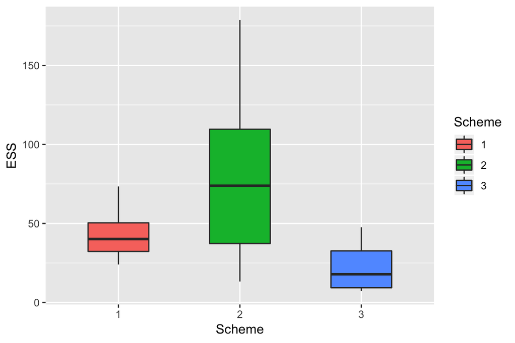

Of course, the ESS does not take into consideration the time it takes to run each scheme: a single large block sampler requires fewer likelihood evaluations than many small block samplers. For this we can calculate the efficiency, i.e., the effective number of samplers per 10 minutes of compute time. Again, first for the mean, nugget variance, anisotropy parameters, and spatial variance hyperparameters:

```
##        Parameter Scheme1 Scheme2 Scheme3
## 1    Sigma_coef1    21.5    15.5    10.2
## 2    Sigma_coef2    18.1    13.1     8.8
## 3    Sigma_coef3    56.7    40.8    33.4
## 4        beta[1]    70.3    59.2    30.2
## 5        beta[2]   104.5   147.0    57.4
## 6       delta[1]    35.6    41.4    23.3
## 7       delta[2]    39.4    34.9    25.2
## 8     sigmaGP_mu     0.9     1.0     1.1
## 9    sigmaGP_phi     0.9     1.7     0.3
## 10 sigmaGP_sigma     3.7     2.1     1.6
```

and again for the `w_sigma[.]` parameters:

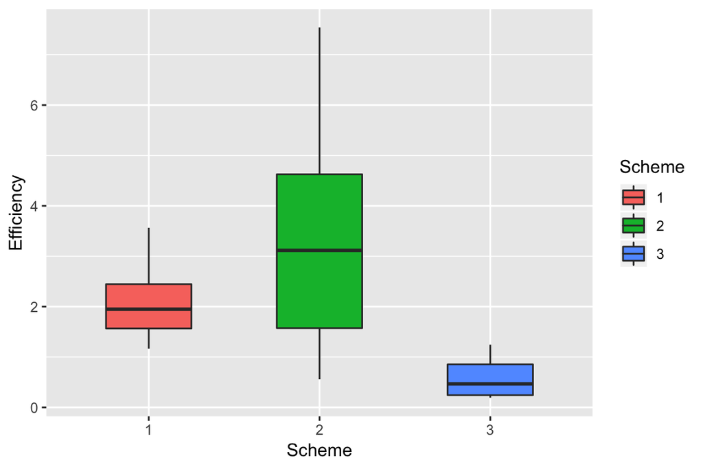

The story is largely the same for both ESS and efficiency: Scheme 2, which compromises between many small blocks and one large block, is the most effective at sampling the highly correlated posterior distribution for the `w_sigma[.]` terms. As such, we will use samples from Scheme 2 in our posterior summaries.

### Posterior summaries

The `samples` object from `runMCMC` is a matrix with one row for each saved MCMC sample (10000 total, thinned from the 50000 post burn-in) and one column for each sampled parameter (26 in this case):

```r
dim(samples)
```

```
## [1] 10000    26
```

```r
head(samples[,1:12])
```

```
##      Sigma_coef1 Sigma_coef2 Sigma_coef3    beta[1]   beta[2]  delta[1]
## [1,]    2.991847   0.7872817   1.3972956 -0.7592755 4.3688278 -1.393588
## [2,]    2.991847   0.7872817   1.1007932 -0.3730407 3.7446745 -1.393588
## [3,]    3.134880   1.0415050   0.9529872  0.3578867 2.5247321 -1.479504
## [4,]    3.134880   1.0415050   1.5499149  0.1121825 1.6613052 -1.323185
## [5,]    3.069375   2.9229506   1.4032121 -0.8030017 3.1579359 -1.011129
## [6,]    3.684056   2.8873857   0.8458632 -0.2209354 0.0213499 -1.504121
##        delta[2]  sigmaGP_mu sigmaGP_phi sigmaGP_sigma w_sigma[1]
## [1,]  0.6283442 -0.28675309    2.629507     0.8378485   3.296471
## [2,]  0.6283442 -0.12389926    2.629507     0.8378485   3.895972
## [3,]  0.8192963 -0.14496049    2.629507     0.8378485   1.484535
## [4,]  0.8705920 -0.09259391    2.812105     0.8914639   2.492000
## [5,] -0.1979030 -0.01575633    2.821764     0.8725914   4.744466
## [6,]  0.7678793 -0.01359778    2.606389     0.8742324   3.097850
##      w_sigma[2]
## [1,]  -16.31427
## [2,]  -17.80954
## [3,]  -14.05882
## [4,]  -17.49371
## [5,]  -21.97207
## [6,]  -21.37898
```

We can then summarize the low level parameters

```r
# Posterior means
apply(samples[,1:10], 2, mean)
```

```
##   Sigma_coef1   Sigma_coef2   Sigma_coef3       beta[1]       beta[2]
##     5.9865916     3.8081879     1.0651081    -0.4854712     2.9933497
##      delta[1]      delta[2]    sigmaGP_mu   sigmaGP_phi sigmaGP_sigma
##    -1.6197360     0.8928848     0.9248680     2.2618455     0.8458431
```

```r
# Posterior standard deviations
apply(samples[,1:10], 2, sd)
```

```
##   Sigma_coef1   Sigma_coef2   Sigma_coef3       beta[1]       beta[2]
##     3.3532366     2.6558587     0.3719001     0.6434408     1.4202927
##      delta[1]      delta[2]    sigmaGP_mu   sigmaGP_phi sigmaGP_sigma
##     0.4703794     1.0880609     0.7086715     0.5346610     0.4005190
```

and examine trace plots:

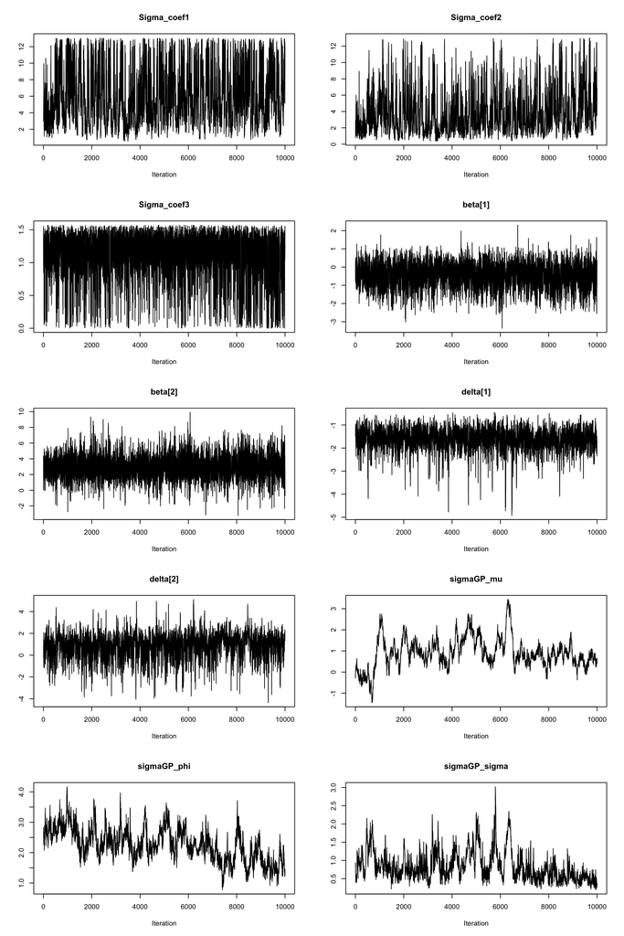

```r
par(mfrow=c(5,2))
for(i in 1:10){
  plot(samples[,i], type = "l", main = colnames(samples)[i], xlab = "Iteration", ylab = "")
}
```

Using these posterior draws, we can also examine how the posterior mean parameter surfaces compare to the truth. We know that the true mean, nugget standard deviation, and spatial standard deviation surfaces are:

```r
gridPlot <- expand.grid(x = seq(0,10,length = 20), y = seq(0,10,length = 20))
gridPlot_z <- gridPlot/10
Xmat1 <- cbind(rep(1,nrow(gridPlot)), gridPlot_z[,1])
Xmat2 <- cbind(rep(1,nrow(gridPlot)), gridPlot_z[,2])
Xmat3 <- cbind(rep(1,nrow(gridPlot)), gridPlot_z[,1], gridPlot_z[,2])
mean_true_grid <- as.numeric(Xmat2 %*% beta_true) # Mean
logNuggSD_true_grid <- as.numeric(Xmat1 %*% delta_true) # Log nugget SD
logSpatSD_true_grid <- as.numeric(Xmat3 %*% alpha_true) # Log spatial SD
```

```r
mu_post <- as.numeric(Xmat2 %*% apply(samples[,4:5], 2, mean)) # Mean
delta_post <- as.numeric(Xmat1 %*% apply(samples[,6:7], 2, mean)) # Log spatial SD
```

```r
p_sigma <- nrow(knot_coords_mat)
sigma_cross_dist_pred <- sqrt(nsCrossdist(knot_coords_mat, gridPlot, isotropic = TRUE)$dist1_sq)
sigma_HP2 <- 5 # Default sigma_HP2 (smoothness for the approx GP)
Psigma <- matrix(NA, nrow(gridPlot), nrow(samples))
for(j in 1:nrow(samples)){
  w_sigma_j <- samples[j,paste("w_sigma[",1:p_sigma,"]",sep = "")]
  Pmat_sigma_j <- matern_corr(sigma_cross_dist_pred, samples[j,"sigmaGP_phi"], sigma_HP2)
  Psigma[,j] <- samples[j,"sigmaGP_mu"]*rep(1,nrow(gridPlot)) + samples[j,"sigmaGP_sigma"] * Pmat_sigma_j %*% w_sigma_j
}
alpha_post <- rowMeans(Psigma) # Log nugget SD
```

The posterior mean surfaces can then be plotted:

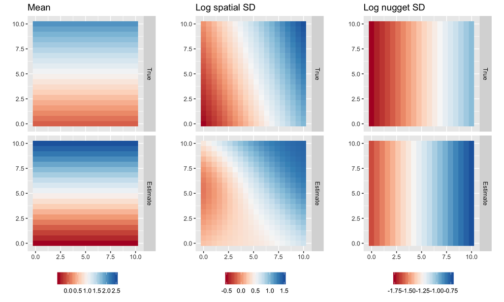

```r
plotDF <- rbind(gridPlot, gridPlot)
plotDF$type <- ordered(rep(c("True","Estimate"), each = nrow(gridPlot)), levels = c("True","Estimate"))
grid.arrange(
  ggplot(plotDF, aes(x = x, y = y, fill = c(mean_true_grid, mu_post))) + geom_tile() +
    scale_fill_gradientn(colors = brewer.pal(9, "RdBu"), name = "") + facet_grid( type ~ . ) +
    coord_fixed() + ggtitle("Mean") + labs(x = NULL, y = NULL) +
    theme(legend.position = "bottom", legend.direction = "horizontal"),
  ggplot(plotDF, aes(x = x, y = y, fill = c(logSpatSD_true_grid,alpha_post)) ) + geom_tile() +
    scale_fill_gradientn(colors = brewer.pal(9, "RdBu"), name = "") + facet_grid( type ~ . ) +
    coord_fixed() + ggtitle("Log spatial SD") + labs(x = NULL, y = NULL) +
    theme(legend.position = "bottom", legend.direction = "horizontal"),
  ggplot(plotDF, aes(x = x, y = y, fill = c(logNuggSD_true_grid,delta_post)) ) + geom_tile() +
    scale_fill_gradientn(colors = brewer.pal(9, "RdBu"), name = "") + facet_grid( type ~ . ) +
    coord_fixed() + ggtitle("Log nugget SD") + labs(x = NULL, y = NULL) +
    theme(legend.position = "bottom", legend.direction = "horizontal"),
  ncol = 3
)
```

### Posterior prediction

Using `samples`, the matrix of posterior samples generated from the MCMC, we can proceed with posterior prediction as follows. Note that we require prediction locations (defined on a grid), as well as corresponding design matrices:

```r
M <- 20^2
predCoords <- as.matrix(expand.grid(seq(0,10,length = sqrt(M)),seq(0,10,length = sqrt(M))))
Xmat1_pred <- cbind(rep(1,M), predCoords[,1]/10)
Xmat2_pred <- cbind(rep(1,M), predCoords[,2]/10)

pred_constants <- list( PX_tau = Xmat1_pred, PX_mu = Xmat2_pred )
pred <- nsgpPredict(model = Rmodel, samples = samples,
                    coords.predict = predCoords,
                    constants = pred_constants)
```

The posterior predictive mean and standard deviation surfaces are:

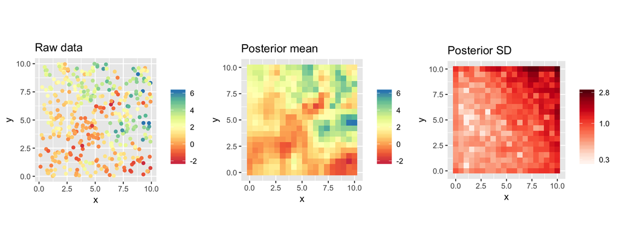

```r
dataPlot <- data
dataPlot[data>=6.2] <- 6.2
dataPlot[data<=-2.15] <- -2.15
grid.arrange(
  ggplot(data.frame(x = coords[,1], y = coords[,2]),
         aes(x = x, y = y, color = dataPlot)) + geom_point() +
    scale_color_gradientn(colors = brewer.pal(9, "Spectral"), name = "") +
    coord_fixed() + ggtitle("Raw data"),
  ggplot(data.frame(x = predCoords[,1], y = predCoords[,2]),
         aes(x = x, y = y, fill = apply(pred$pred, 2, mean))) + geom_tile() +
    scale_fill_gradientn(colors = brewer.pal(9, "Spectral"), name = "", limits = c(-2.15,6.2)) +
    coord_fixed() + ggtitle("Posterior mean"),
  ggplot(data.frame(x = predCoords[,1], y = predCoords[,2]),
         aes(x = x, y = y, fill = apply(pred$pred, 2, sd))) + geom_tile() +
    scale_fill_gradientn(colors = brewer.pal(9, "Reds"), trans = "log", name = "", breaks = c(0.3,1,2.8)) +
    coord_fixed() + ggtitle("Posterior SD"),
  ncol = 3
)
```